# PAC2_carles_trullas

[figure not shown]

M2.991 · Aprenentatge automàtic · PEC2

2025-2 · Màster universitari en Ciència de dades (Data science)

Estudis d'Informàtica, Multimèdia i Telecomunicació

**PEC 2: Aprenentatge no supervisat**

Al llarg d'aquesta pràctica veurem com aplicar distintes tècniques no supervisades: clustering de blobs clàssics (*k-means* i la regla del colze), clustering amb formes i feature engineering.

Així com algunes de les seves aplicacions reals: reducció de dimensionalitat, agrupació i generació d'imatges.

**Notes importants:**

- Cadascun dels exercicis pot suposar diversos minuts d'execució, per la qual cosa el lliurament s'ha de fer en format notebook i en format html, on es vegi el codi, els resultats i comentaris de cada exercici. Es pot exportar el notebook a html des del menú File $\to$ Download as $\to$ HTML.
- Existeix un tipus de celda especial per a allotjar text. Aquest tipus de celda us serà molt útil per a respondre a les diferents preguntes teòriques plantejades al llarg de cada PEC. Per a canviar el tipus de celda a aquest tipus, trieu en el menú: Cell $\to$ Cell Type $\to$ Markdown.
- La solució plantejada no ha d'utilitzar mètodes, funcions o paràmetres declarats "deprecated" en futures versions.
- És convenient que utilitzeu una llavor amb un valor fix (en aquest Notebook se us proposa la variable *seed* inicialitzada a 100) en tots aquells mètodes o funcions que continguin alguna component aleatòria per a assegurar-vos que obtindreu sempre el mateix resultat en les distintes execucions del vostre codi.
- No es permet l'ús d'eines d'intel·ligència artificial per a resoldre les qüestions de la PEC.
- No oblideu posar el vostre nom i cognoms en la següent celda.

**AVÍS:** tingueu cura, més podria ser menys. Si us excediu en les respostes, podríeu tenir penalització en la nota. Sigueu concisos, sintetitzeu el que voleu remarcar i aneu al gra si us plau.

**Nom i cognoms: Carles Trullàs Fernández**

```python
import random

import matplotlib.pyplot as plt
import numpy as np
import pandas as pd
from scipy.cluster.hierarchy import dendrogram, linkage, fcluster
from scipy.stats import mode
import seaborn as sns
from sklearn import cluster, datasets, manifold, decomposition, ensemble
from sklearn.metrics import adjusted_rand_score, confusion_matrix
from sklearn.preprocessing import MinMaxScaler
from umap import UMAP

seed = 100
random.seed(seed)
np.random.seed(seed)
```

## 1. Clustering clàssic (4 punts)

### 1.1 Clustering de blobs: *k-means* i la regla del colze

Anem a generar un dataset compost per $n$ núvols de punts, on $n$ serà un número aleatori entre 2 i 4, usant el mòdul `datasets` de scikit-learn.

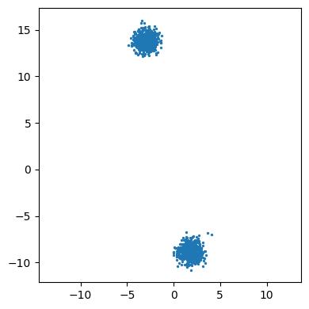

```python
N_SAMPLES = 1500
MIN_CLUSTERS = 2
MAX_CLUSTERS = 4
n_blobs = random.randint(MIN_CLUSTERS, MAX_CLUSTERS)
X, y = datasets.make_blobs(n_samples=N_SAMPLES,
                           n_features=2,
                           centers=n_blobs,
                           center_box=(-20, 20),
                           cluster_std=.6,
                           random_state=seed)

fig, ax = plt.subplots(1, 1, figsize=(4, 4))
ax.scatter(X[:,0], X[:,1], s=2)
ax.axis('equal')
plt.tight_layout()
```

Una tècnica per a estimar $k$ és, tal com s'explica en la teoria:

> Els criteris anteriors (minimització de distàncies intra grup o maximització de distàncies inter grup) poden usar-se per a establir un valor adequat per al paràmetre k. Valors k per als quals ja no s'aconsegueixen millores significatives en l'homogeneïtat interna dels segments o l'heterogeneïtat entre segments distints, haurien de descartar-se.

El que popularment es coneix com a *regla del colze*.

Primer és necessari calcular la suma dels errors quadràtics ([*SSE*](https://bl.ocks.org/rpgove/0060ff3b656618e9136b)) que consisteix en la suma de tots els errors (distància de cada punt al seu centroide assignat) al quadrat.

$$SSE = \sum_{i=1}^{K} \sum_{x \in C_i} euclidean(x, c_i)^2$$

On $K$ és el nombre de clusters a buscar per *k-means*, $x \in C_i$ són els punts que pertanyen a l'i-èsim cluster, $c_i$ és el centroide del cluster $C_i$ (al qual pertany el punt $x$), i $euclidean$ és la [distància euclidiana](https://en.wikipedia.org/wiki/Euclidean_distance).

Aquest procediment realitzat per a cada possible valor $k$, resulta en una funció monòtona decreixent, on l'eix $x$ representa els distints valors de $k$, i l'eix $y$ el $SSE$. Intuïtivament es podrà observar un significatiu descens de l'error, que indicarà el valor idoni de $k$.

**Implementació:** càlcul i visualització de la regla del colze.

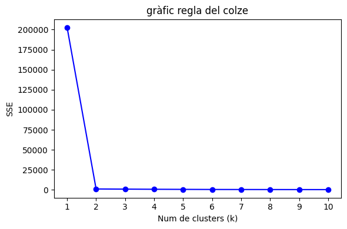

```python
# Fem el càlcul del SSE per a diferents valors de k
k_range = range(1, 11)
sse = []

for k in k_range:
    km = cluster.KMeans(n_clusters=k, random_state=seed, n_init=10)
    km.fit(X)
    sse.append(km.inertia_)

# Visualitzem la regla del colze
fig, ax = plt.subplots(1, 1, figsize=(6, 4))
ax.plot(list(k_range), sse, 'bo-')
ax.set_xlabel('Num de clusters (k)')
ax.set_ylabel('SSE')
ax.set_title('gràfic regla del colze')
ax.set_xticks(list(k_range))
plt.tight_layout()
```

**Anàlisi:** Què s'interpreta en la gràfica? Com podria millorar-se l'elecció de k?.

A la gràfica s'observa una millora molt gran del SEE quan passem de k=1 a k=2. Això és 100% raonable ja que aquest cas preparat l'hem generat amb k=2. La millora per valors de k més grans que 2 és completament residual.

El SEE només té en compte que els clusters estiguin ben agrupats, però no té en compte la separació entre els clusters.

Si ens fixem, el el fet que per k més gran que 2 no hi hagi millora, vol dir que per exemple en el cas k=3, segurament s'està dividint un dels dos clústers en 2. Això obviament fa millorar el SEE, però no és correcte des del punt de vista de clusterització, ja que si dividim un dels dos clústers en dos, clarament tindrem dos clústers junts que realment haurien de ser un de sol.

És per això que necessitem una mètrica que tingui en compte tant la cohesió interna dels clústers com la distància entre els clústers.

Una mètrica que té en compte tant la cohesió dels clústers com la separació es el silhouette score. En aquest cas ens hagués anat millor.

### 1.2 Clustering amb formes i feature engineering

Però no tots els datasets són com els de l'exercici anterior. Per a aquesta segona part anem a emprar el següent conjunt de dades:

```python
data_circles = ('circles', *datasets.make_circles(n_samples=N_SAMPLES, factor=.5, noise=.05))
```

```python
data_circles
```

```
('circles',
 array([[-0.5827475 , -0.10978557],
        [-0.43814186,  0.10156102],
        [-0.44640627, -0.12648475],
        ...,
        [-1.02962202,  0.17998748],
        [ 0.79245457,  0.63402635],
        [ 0.53127442,  0.19945321]], shape=(1500, 2)),
 array([1, 1, 1, ..., 0, 0, 1], shape=(1500,)))
```

On *data_circles* és una tupla amb tres posicions: el nom del dataset i els dos valors retornats per la funció que genera el dataset:

```python
datasets.make_circles?
```

```
Signature:
datasets.make_circles(
    n_samples=100,
    *,
    shuffle=True,
    noise=None,
    random_state=None,
    factor=0.8,
)
Docstring:
Make a large circle containing a smaller circle in 2d.

A simple toy dataset to visualize clustering and classification
algorithms.

Read more in the :ref:`User Guide <sample_generators>`.

Parameters
----------
n_samples : int or tuple of shape (2,), dtype=int, default=100
    If int, it is the total number of points generated.
    For odd numbers, the inner circle will have one point more than the
    outer circle.
    If two-element tuple, number of points in outer circle and inner
    circle.

    .. versionchanged:: 0.23
       Added two-element tuple.

shuffle : bool, default=True
    Whether to shuffle the samples.

noise : float, default=None
    Standard deviation of Gaussian noise added to the data.

random_state : int, RandomState instance or None, default=None
    Determines random number generation for dataset shuffling and noise.
    Pass an int for reproducible output across multiple function calls.
    See :term:`Glossary <random_state>`.

```

[output cut: 8 more lines]

```
y : ndarray of shape (n_samples,)
    The integer labels (0 or 1) for class membership of each sample.

Examples
--------
>>> from sklearn.datasets import make_circles
>>> X, y = make_circles(random_state=42)
>>> X.shape
(100, 2)
>>> y.shape
(100,)
>>> list(y[:5])
[np.int64(1), np.int64(1), np.int64(1), np.int64(0), np.int64(0)]
File:      c:\users\carlestf\miniconda3\envs\uoc2026pec2\lib\site-packages\sklearn\datasets\_samples_generator.py
Type:      function
```

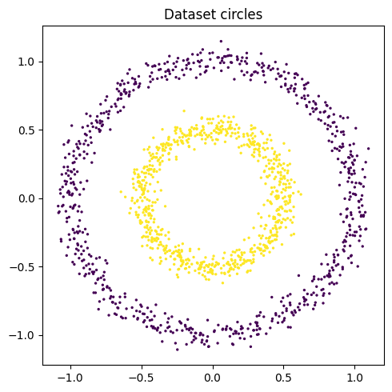

```python
fig, ax = plt.subplots(1, 1, figsize=(5, 5))
ax.scatter(data_circles[1][:,0], data_circles[1][:,1], c=data_circles[2], s=2)
ax.set_title('Dataset {}'.format(data_circles[0]))
plt.tight_layout()
```

#### 1.2.1 Trobant els clústers amb *k-means*

**Implementació:** aplica la regla del colze per decidir el valor de k.

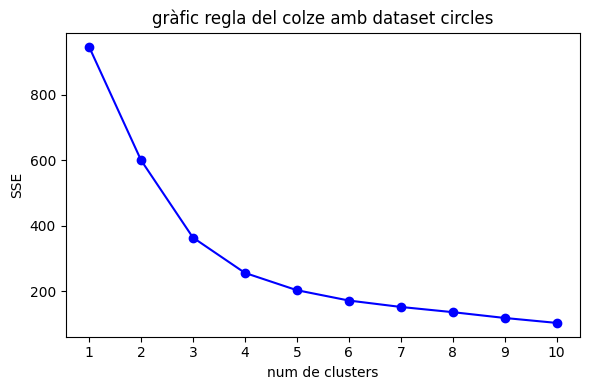

```python
# Tornem a aplicar la regla dels colzes
k_range_circles = range(1, 11)
sse_circles = []

for k in k_range_circles:
    km = cluster.KMeans(n_clusters=k, random_state=seed, n_init=10)
    km.fit(data_circles[1])
    sse_circles.append(km.inertia_)

# grafiquem la funció SSE per a cada valor de k
fig, ax = plt.subplots(1, 1, figsize=(6, 4))
ax.plot(list(k_range_circles), sse_circles, 'bo-')
ax.set_xlabel('num de clusters')
ax.set_ylabel('SSE')
ax.set_title('gràfic regla del colze amb dataset circles')
ax.set_xticks(list(k_range_circles))
plt.tight_layout()
```

**Implementació:** aplica *k-means* amb el valor de k triat.  
Visualitza el resultat en un *scatter plot* representant cada cluster amb un color distint.

Escollim k=5, ja que és el valor de k a partir del qual ja no s'observa una millora significativa.

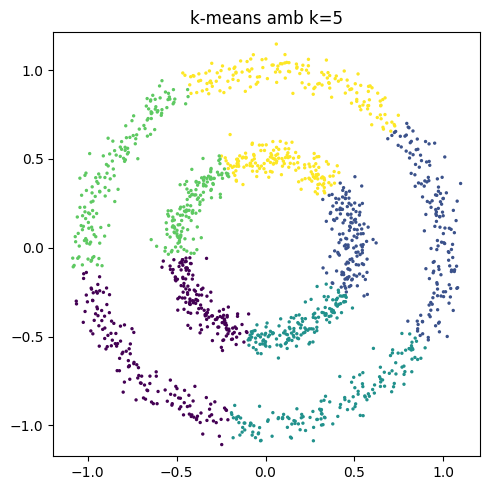

```python
# Apliquem k-means amb k=5
km_circles = cluster.KMeans(n_clusters=5, random_state=seed, n_init=10)
labels_kmeans_circles = km_circles.fit_predict(data_circles[1])

fig, ax = plt.subplots(1, 1, figsize=(5, 5))
ax.scatter(data_circles[1][:,0], data_circles[1][:,1], c=labels_kmeans_circles, s=2, cmap='viridis')
ax.set_title('k-means amb k=5')
ax.axis('equal')
plt.tight_layout()
```

**Anàlisi:** Què ha succeït? Explica els motius pels quals creus que s'ha produït aquest resultat.

Clarament k-means no ha pogut separar els dos cercles concèntrics. Ha fet com una mena de "pizza" en 5 trossos.

El motiu de que això hagi passat és que k-means està pensat per detectar clústers, on s'assumeix que un clúster te una forma bastant esfèrica i convexa. En el cas dels dos cercles concèntrics, no compleixen la intuïció de clúster que pretén trobar k-means. De fet, fixem-nos que cada cercle concèntric té el mateix centroide.

Si volem que cada cercle concèntric representi un clúster, necessitem un altre concepte de clúster. El més raonable en aquest cas seri usar el concepte de densitat.

#### 1.2.2 Més enllà de K-Means: algorismes basats en densitat

En aquest apartat es demana aplicar clustering per densitat com DBSCAN al dataset anterior per poder trobar els dos clusters inicials.

**Implementació:** prova la implementació de [DBSCAN en scikit-learn](http://scikit-learn.org/stable/modules/generated/sklearn.cluster.DBSCAN.html) jugant amb els paràmetres *eps* i *min_samples* per trobar les 2 estructures subjacents (i *outliers*).

```
clusters: 2, outliers: 0
```

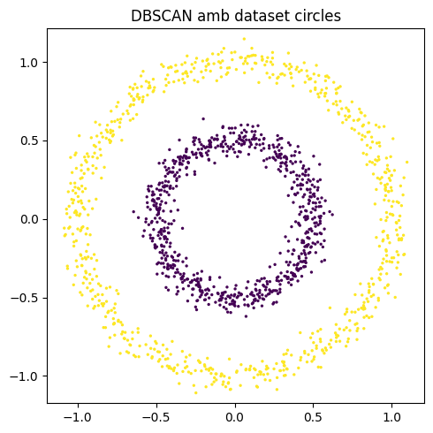

```python
# Aquests params eps i min_samples m'han funcionat bé
dbscan_circles = cluster.DBSCAN(eps=0.15, min_samples=5)
labels_dbscan_circles = dbscan_circles.fit_predict(data_circles[1])

n_clusters_found = len(set(labels_dbscan_circles)) - (1 if -1 in labels_dbscan_circles else 0)
n_outliers = list(labels_dbscan_circles).count(-1)
print(f"clusters: {n_clusters_found}, outliers: {n_outliers}")

fig, ax = plt.subplots(1, 1, figsize=(5, 5))
ax.scatter(data_circles[1][:,0], data_circles[1][:,1], c=labels_dbscan_circles, s=2, cmap='viridis')
ax.set_title('DBSCAN amb dataset circles')
ax.axis('equal')
plt.tight_layout()
```

**Anàlisi:** Què ha succeït? Explica els motius pels quals creus que s'ha produït aquest resultat.

En aquest cas, DBSCAN ha "trobat" correctament els dos cercles. Com que DBSCAN és un algorisme basat en densitat, agrupa punts que estan connectats entre si de manera "densa". És a dir, q com els punts de cada cercle formen regions "contínues", DBSCAN pot detectar les dues peçes circulars (i sense assumir cap forma concreta dels clusters!). Per tant en aquest cas ens va perfecte.

Els punts que queden aïllats (outliers) tenen etiqueta -1. En aquest cas és normal que no n'haguem trobat cap ja que això és un dataset completament artificial, en el qual els cercles estan molt marcats.

#### 1.2.3 Més enllà de K-Means: algorismes jeràrquics

En aquest apartat es demana visualitzar mitjançant un [dendrograma](https://en.wikipedia.org/wiki/Dendrogram) la construcció progressiva dels grups mitjançant un algorisme jeràrquic aglomeratiu (estratègia *bottom-up*). Amb això es pretén trobar un mètode gràfic per entendre el comportament de l'algorisme i trobar els dos clusters.

**Implementació:**

Prova la implementació de [clustering jeràrquic de scipy](https://docs.scipy.org/doc/scipy/reference/cluster.hierarchy.html) provant distints [criteris d'enllaç o *linkage*](https://en.wikipedia.org/wiki/Hierarchical_clustering#Linkage_criteria) permetent identificar els clusters subjacents (mostrant el seu resultat) i el seu dendrograma.

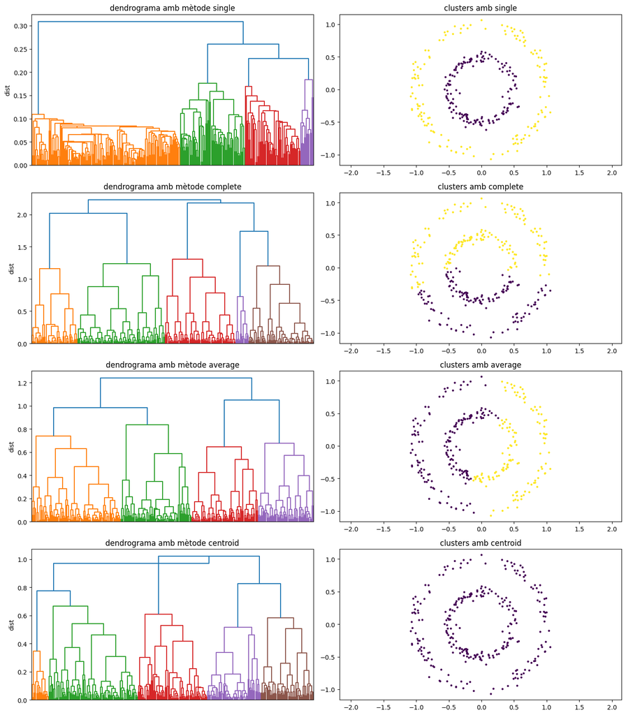

```python
# per reduir el temps de càlcul utilitzem un subset
np.random.seed(seed)
sample_idx = np.random.choice(len(data_circles[1]), size=300, replace=False)
X_sample = data_circles[1][sample_idx]
y_sample = data_circles[2][sample_idx]

# probarem els següents criteris d'enllaç (que són els que hem vist a teoria)
linkage_methods = ['single', 'complete', 'average', 'centroid']

fig, axes = plt.subplots(len(linkage_methods), 2, figsize=(14, 4 * len(linkage_methods)))

for i, method in enumerate(linkage_methods):
    # apliquem l'aloritme de clustering jeràrquic
    Z = linkage(X_sample, method=method)

    # obtenim el dendograma
    dendrogram(Z, ax=axes[i, 0], no_labels=True)
    axes[i, 0].set_title(f'dendrograma amb mètode {method}')
    axes[i, 0].set_ylabel('dist')

    # obtenim les etiquetes retallant a 2 clusters
    labels_hier = fcluster(Z, t=2, criterion='maxclust')

    axes[i, 1].scatter(X_sample[:,0], X_sample[:,1], c=labels_hier, s=5, cmap='viridis')
    axes[i, 1].set_title(f'clusters amb {method}')
    axes[i, 1].axis('equal')

plt.tight_layout()
```

**Anàlisi:** Interpreta el dendrograma i comenta quin criteri d'enllaç s'ha comportat millor. Per què?

Clarament el mètode d'enllaç que s'ha comportat millor és el simple. Tal i com podem veure, ha pogut separar els dos centres concèntrics perfectament. A més, al dendograma de l'enllaç simple s'observa una clara separació en dos grups a distàncies baixes.

Els altres tres mètodes d'enllaç no han sabut separar correctament els cercles concèntrics.

**Anàlisi:** Què ha succeït? Explica els motius pels quals creus que s'ha produït aquest resultat.

Tal i com vam veure a la teoria, l’enllaç simple assumeix que la mesura de similitud és transitiva (és a dir, que si A està prob de B i B està prop de C, aleshores A està prop de C). Això només és aplicable en alguns casos, i justament per detectar estructures no convexes però continues va perfecte.

En canvi, els enllaços mitjà i complet tendeixen a buscar clusters compactes i esfèrics, similar a k-means, i per tant no han separat correctament les estructures circulars.

Pel que fa a l'enllaç centroide, donat que les dues estructures circulars tenen el mateix centroide, ha generat un únic clúster, tal i com era d'esperar.

### 1.3 *Feature engineering* i agrupament

Alguns dels algorismes anteriors es basen en unes suposicions que no es complien en el dataset. Moltes vegades en lloc d'optar per algorismes més complexos o que requereixen major còmput, es poden transformar les dades per poder aplicar amb èxit tècniques més simples. Això és un clar exemple de *feature engineering*.

**Anàlisi:** Creus que podrien trobar els dos grups amb k-means? Per què?

Si, si transformem les dades a coordenades polars (radi i angle), els dos cercles concèntrics es separaran en dos grups amb radis diferents.

**Implementació:** transforma els punts anteriors del dataset a un nou espai de 2 dimensions:

- Radi, o distància al punt (0,0)
- Angle, respecte al vector (1,0)

Perquè totes les dimensions tinguin el mateix pes, a més anem a [normalitzar-les entre 0 i 1 d'acord amb el seu màxim i mínim](http://scikit-learn.org/stable/modules/generated/sklearn.preprocessing.MinMaxScaler.html).  
Visualitzar els punts del "nou" dataset.

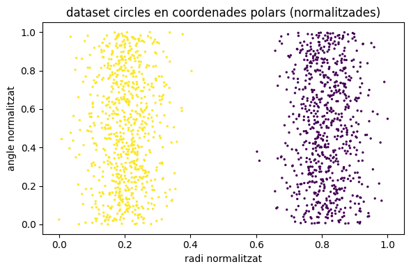

```python
# transformem a polars
X_circles = data_circles[1]
radius = np.sqrt(X_circles[:,0]**2 + X_circles[:,1]**2)
angle = np.arctan2(X_circles[:,1], X_circles[:,0])

X_polar = np.column_stack([radius, angle])

# normalitzem entre 0 i 1
scaler = MinMaxScaler()
X_polar_scaled = scaler.fit_transform(X_polar)

fig, ax = plt.subplots(1, 1, figsize=(6, 4))
ax.scatter(X_polar_scaled[:,0], X_polar_scaled[:,1], c=data_circles[2], s=2, cmap='viridis')
ax.set_xlabel('radi normalitzat')
ax.set_ylabel('angle normalitzat')
ax.set_title('dataset circles en coordenades polars (normalitzades)')
plt.tight_layout()
```

**Anàlisi:** Què creus que succeirà en aplicar els anteriors algorismes en aquest "nou" dataset?

- DBSCAN i el clustering jeràrquic single seguiran funcionant.
- K-means ara si que funcionarà.
- Jeràrquic amb centroide i jeràrquic amb enllaç mitjà també funcionaràn.
- Em queda el dubte de jeràrquic amb enllaç complet, ja que els dos radis no són gaire diferents, i és un tipus d'enllaç que podria generar efecte cadena.

**Implementació:** aplica cadascun dels algorismes d'agrupament anteriors que no hagin pogut localitzar adequadament els dos clusters originals per tractar de trobar-los en aquest "nou" espai. Ajusta els paràmetres necessaris per facilitar la seva detecció.  
Per a cada algorisme, visualitza els clusters trobats en 2 imatges:

- En el "nou" espai (radi i angle).
- En l'espai original (posició x i y), però NO amb les etiquetes (pertinença al cluster) obtingudes en aplicar els algorismes sobre el dataset original, sinó amb les etiquetes obtingudes en realitzar el clustering en el "nou" espai. A veure si així s'aconsegueixen solucionar els problemes inicials.

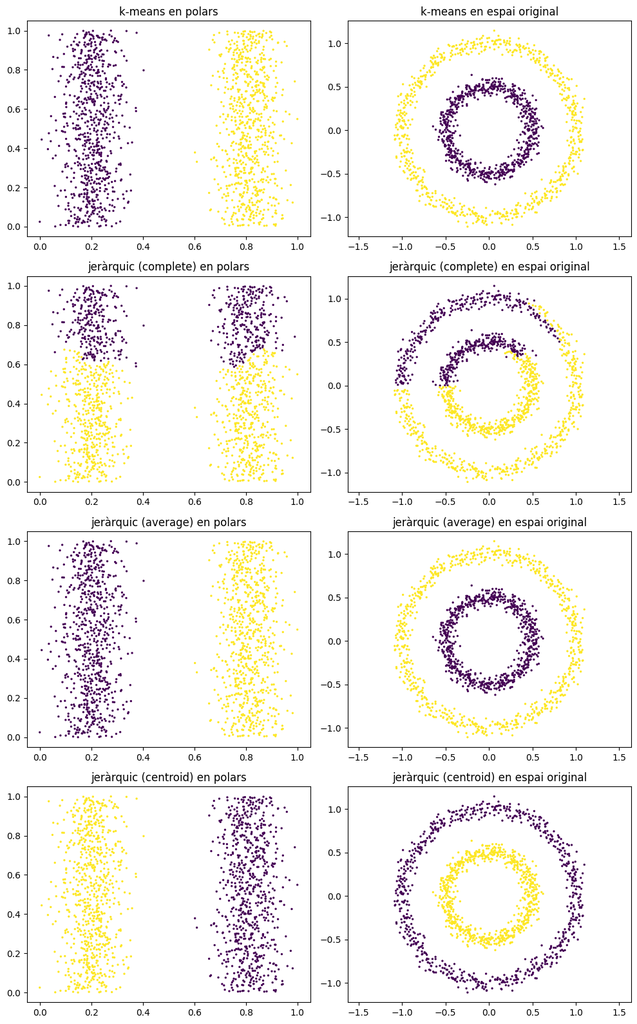

```python
# algoritmes que no han funcionat: k-means, complete, average, centroid
fig, axes = plt.subplots(4, 2, figsize=(10, 16))

# apliquem k-means
labels_km_polar = cluster.KMeans(n_clusters=2, random_state=seed, n_init=10).fit_predict(X_polar_scaled)
axes[0, 0].scatter(X_polar_scaled[:,0], X_polar_scaled[:,1], c=labels_km_polar, s=2, cmap='viridis')
axes[0, 0].set_title('k-means en polars')
axes[0, 1].scatter(X_circles[:,0], X_circles[:,1], c=labels_km_polar, s=2, cmap='viridis')
axes[0, 1].set_title('k-means en espai original')
axes[0, 1].axis('equal')

# apliquem clustering jeràrquic amb complete, average i centroid
for i, method in enumerate(['complete', 'average', 'centroid']):
    Z = linkage(X_polar_scaled, method=method)
    labels_hier_polar = fcluster(Z, t=2, criterion='maxclust')

    axes[i+1, 0].scatter(X_polar_scaled[:,0], X_polar_scaled[:,1], c=labels_hier_polar, s=2, cmap='viridis')
    axes[i+1, 0].set_title(f'jeràrquic ({method}) en polars')
    axes[i+1, 1].scatter(X_circles[:,0], X_circles[:,1], c=labels_hier_polar, s=2, cmap='viridis')
    axes[i+1, 1].set_title(f'jeràrquic ({method}) en espai original')
    axes[i+1, 1].axis('equal')

plt.tight_layout()
```

Com sospitavem, han funcionat tots excepte el jeràrquic amb max (és a dir, complete), ja que els dos radis són molt semblants i s'ha produït l'efecte cadena a l'espai en coordenades polars.

## 2. Descobrint grups d'imatges (6 punts)

En plantejar un problema de classificació amb un dataset de més de tres atributs (dimensions), no es pot realitzar una visualització clàssica del dataset per entendre les dades. Per això, un dels usos dels mètodes de reducció de dimensionalitat és transformar les dades de més de 4 dimensions a 3 o menys per poder visualitzar-les.

### 2.1 Anàlisi de dades

El [dataset Iris](https://es.wikipedia.org/wiki/Iris_flor_conjunto_de_datos) conté 4 atributs sobre tres tipus de flors.

```python
iris = datasets.load_iris()
X = iris.data   # np.array con shape (150, 4)
y = iris.target # np.array con shape (150,)
```

Al excedir les 3 dimensions necessitarem més d'una visualització per entendre les dades.

Per solucionar-ho, una alternativa és usar els [*pair plots*](http://seaborn.pydata.org/generated/seaborn.pairplot.html) que enfronten parells de dimensions per tractar de donar una visió global a partir d'un [DataFrame](https://pandas.pydata.org/pandas-docs/stable/dsintro.html):

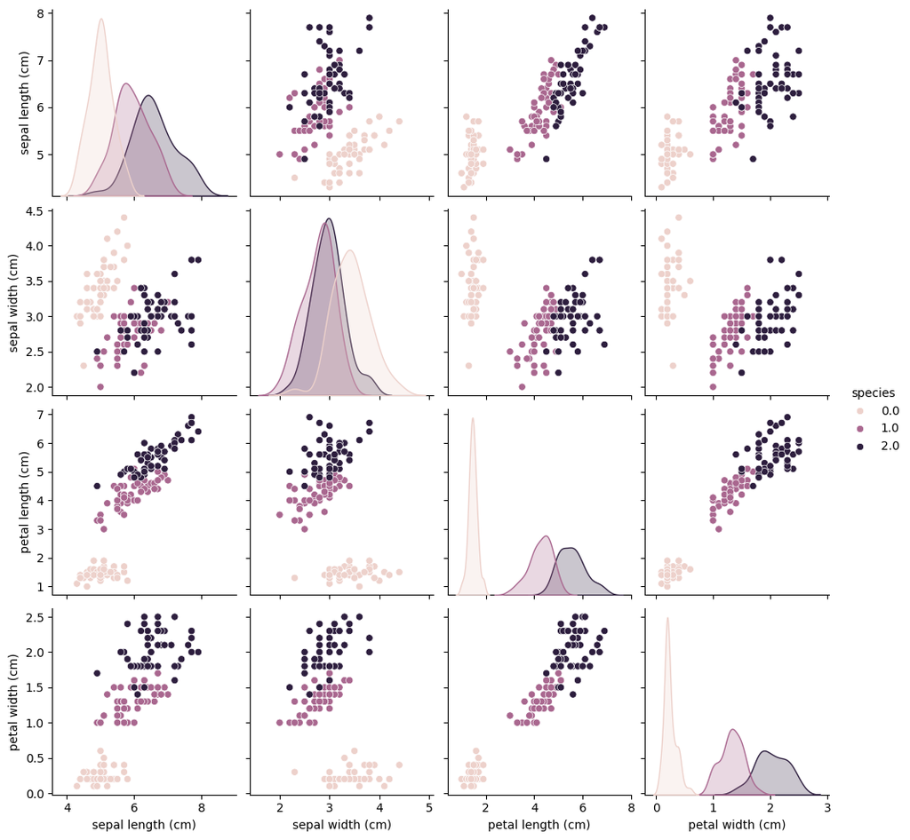

```python
iris_df = pd.DataFrame(np.hstack([X, y.reshape(-1, 1)]), columns=iris.feature_names + ['species'])
sns.pairplot(iris_df, vars=iris.feature_names, hue="species")
```

### 2.2 Reducció de dimensionalitat

Com a alternativa a les múltiples gràfiques que generen els gràfics aparellats, es planteja utilitzar una tècnica de reducció de dimensionalitat per passar de 4 dimensions a 2. Noti's que gràfiques com *longitud de pètal* vs *amplada de pètal* mostren certa separabilitat (els 3 tipus de flors estan aparentment separats).

**Implementació:** realitzar una reducció de dimensionalitat amb PCA per passar de 4 dimensions a 2 i crear una visualització on el color dels punts depengui del tipus de flor a la qual pertany.

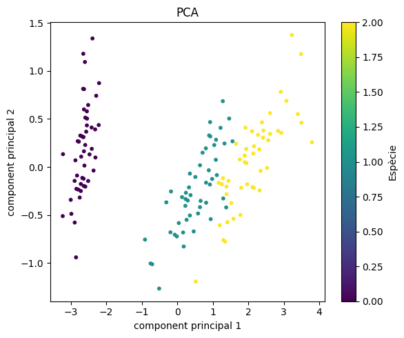

```python
# PCA per passar de 4D a 2D
iris = datasets.load_iris()
X_iris = iris.data
y_iris = iris.target

pca_iris = decomposition.PCA(n_components=2)
X_iris_pca = pca_iris.fit_transform(X_iris)

fig, ax = plt.subplots(1, 1, figsize=(6, 5))
scatter = ax.scatter(X_iris_pca[:,0], X_iris_pca[:,1], c=y_iris, s=10, cmap='viridis')
ax.set_xlabel('component principal 1')
ax.set_ylabel('component principal 2')
ax.set_title('PCA')
plt.colorbar(scatter, ax=ax, label='Espècie')
plt.tight_layout()
```

**Anàlisi:** El resultat de la reducció de dimensionalitat manté la separabilitat? PCA ens ajuda a la separabilitat? Per què?

Jo diria que ens ajuda parcialment. En efecte, l'espècie 0 està clarament separada de les altres dues, però les espècies 1 i 2 estan molt juntes, i podrien interpretar-se com un únic clúster.

De fet, si no sabéssim a quina espècie pertany cada mostra, segurament en veure el dataset anterior la nostre primera reacció seria pensar que només hi ha dos clústers.

Conclusió: obviament la PCA té grans avantatges, però hem de vigilar.

L'ús de tècniques de reducció de dimensionalitat és de gran utilitat quan aquesta és molt alta. Per exemple, el [dataset Digits](http://scikit-learn.org/stable/auto_examples/classification/plot_digits_classification.html) conté 1797 imatges de números del 0 al 9, de 8 per 8 píxels. Si es pren cada píxel com una dimensió, això es tradueix en el fet que cada mostra té 64 dimensions!

```python
digits = datasets.load_digits()
X = digits.data   # np.array con shape (1797, 64)
y = digits.target # np.array con shape (1797,)

n_clusters = 10
```

Exemple dels 24 primers dígits de 8 per 8 píxels juntament amb la seva etiqueta presents en el dataset:

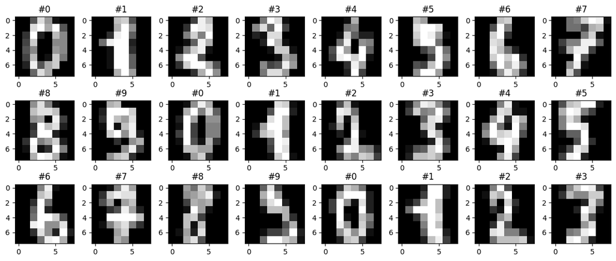

```python
fig, ax = plt.subplots(3, 8, figsize=(12, 5))
for i, axis in zip(range(24), ax.reshape(-1)):
    axis.imshow(X[i,:].reshape(8, 8), cmap='gray')
    axis.set_title('#{}'.format(y[i]))
plt.tight_layout()
```

Amb un número tan elevat de dimensions perd sentit visualitzar el dataset amb un *pair plot* i apareixen altres perills com la [maledicció de la dimensionalitat](https://es.wikipedia.org/wiki/Maldici%C3%B3n_de_la_dimensi%C3%B3n). Per reduir la seva dimensió i així entendre l'estructura de les dades en alta dimensionalitat existeixen distintes alternatives amb resultats molt distints.

**Implementació:** realitzar una reducció de dimensionalitat amb PCA per passar de 64 dimensions a 2 i crear una visualització on el color dels punts depengui del dígit al qual pertany.

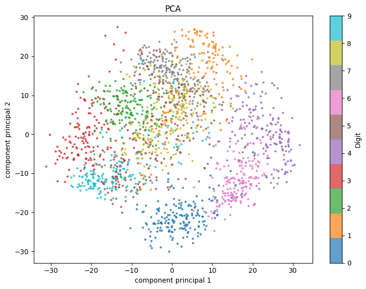

```python
pca_digits = decomposition.PCA(n_components=2)
X_digits_pca = pca_digits.fit_transform(X)

fig, ax = plt.subplots(1, 1, figsize=(8, 6))
scatter = ax.scatter(X_digits_pca[:,0], X_digits_pca[:,1], c=y, s=5, cmap='tab10', alpha=0.7)
ax.set_xlabel('component principal 1')
ax.set_ylabel('component principal 2')
ax.set_title('PCA')
plt.colorbar(scatter, ax=ax, label='Dígit')
plt.tight_layout()
```

**Anàlisi:** El resultat de la reducció de dimensionalitat manté la separabilitat? Era d'esperar? Per què?

El resultat de la pca mostra una separació parcial dels dígits. Alguns dígits (per exemple el 0) es distingeixen relativament bé, però en general hi ha molta superposició entre classes.

Evidentment era d'esperar, ja que la pca selecciona des direccions de màxima variança, però amb només 2 components de 64 originals és d'esperar que es perdi molta informació.

Reduir la dimensionalitat té una gran implicació: la pèrdua d'informació. Però en quin grau afecta la dada?

**Implementació:** Tria una mostra aleatòria o concreta del dataset i visualitza-la. Després redueix la dimensionalitat de tot el dataset a 1, 2, 3... fins a 40 dimensions amb PCA i inverteix el procés tractant de reconstruir les "imatges originals". Amb això fes dues coses: (1) Visualitza la imatge resultant de la reconstrucció de la mostra triada després de la reducció a 1, 2, ..., 5 dimensions. (2) Calcula l'error quadràtic mig (MSE) del dataset reconstruït respecte a l'original i visualitza l'error de reconstrucció en funció del nombre de dimensions al qual ha estat reduït (de 1 a 40 dimensions).

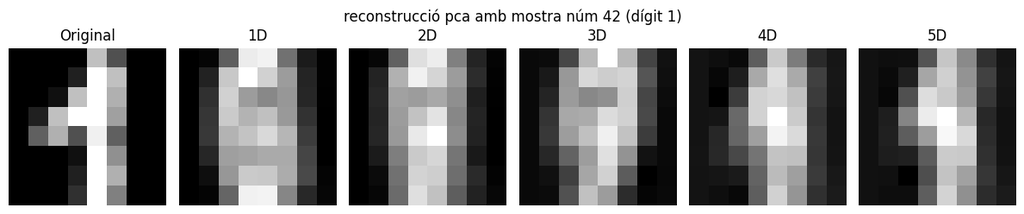

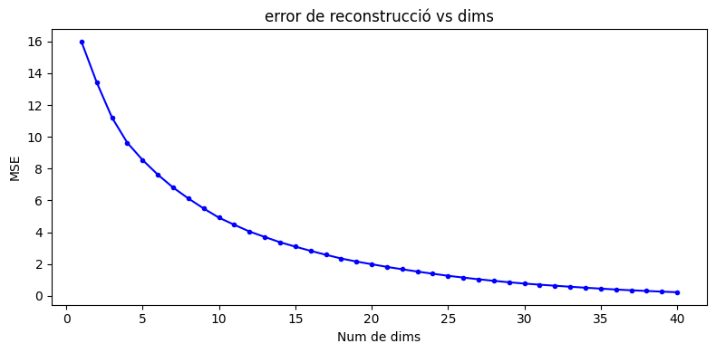

```python
# Mostra triada
sample_idx_digit = 42
sample_image = X[sample_idx_digit].reshape(8, 8)

# visualitzem la reconstrucció per a 1,..,5 dimensions
fig, axes = plt.subplots(1, 6, figsize=(12, 2.5))
axes[0].imshow(sample_image, cmap='gray')
axes[0].set_title('Original')

for i, n_comp in enumerate(range(1, 6)):
    pca_temp = decomposition.PCA(n_components=n_comp)
    X_reduced = pca_temp.fit_transform(X)
    X_reconstructed = pca_temp.inverse_transform(X_reduced)
    axes[i+1].imshow(X_reconstructed[sample_idx_digit].reshape(8, 8), cmap='gray')
    axes[i+1].set_title(f'{n_comp}D')

for ax in axes:
    ax.axis('off')
plt.suptitle(f'reconstrucció pca amb mostra núm {sample_idx_digit} (dígit {y[sample_idx_digit]})')
plt.tight_layout()

# Calculem MSE per a diferents dimensions
dims = range(1, 41)
mse_values = []

for n_comp in dims:
    pca_temp = decomposition.PCA(n_components=n_comp)
    X_reduced = pca_temp.fit_transform(X)
    X_reconstructed = pca_temp.inverse_transform(X_reduced)
    mse = np.mean((X - X_reconstructed) ** 2)
    mse_values.append(mse)

fig, ax = plt.subplots(1, 1, figsize=(8, 4))
ax.plot(list(dims), mse_values, 'bo-', markersize=3)
ax.set_xlabel('Num de dims')
ax.set_ylabel('MSE')
ax.set_title('error de reconstrucció vs dims')
plt.tight_layout()
```

**Anàlisi:** Com afecta la reducció de dimensionalitat respecte a la informació mantinguda de la imatge? És lineal la relació? Per què?

La reducció de dimensionalitat amb PCA perd informació, però de manera no lineal. Les primeres components capturen la major part de la variança, de manera que les primeres dimensions afegides redueixen molt l'error.

Les últimes aporten millores petites. Amb approx 15 components ja s'aconsegueix una reconstrucció força bona. Això és pq la PCA ordena les components per variança explicada decreixent (i.e. les primeres components són les que capturen més variança).

L'algorisme [t-SNE](https://en.wikipedia.org/wiki/T-distributed_stochastic_neighbor_embedding) ideat per [van der Maaten i Hinton](https://lvdmaaten.github.io/tsne/) difereix de PCA en el fet que no tracta de maximitzar la variança explicada. Intuïtivament, t-SNE tracta que el veïnat d'un punt en baixa dimensionalitat sigui la mateixa que l'original. Partint d'una localització aleatòria de cada punt, corregeix la seva posició de forma iterativa tractant de minimitzar la distància als seus veïns originals fins a convergir.

Per a això, t-SNE disposa de diversos [paràmetres](https://distill.pub/2016/misread-tsne/) que poden modificar dràsticament el resultat. Pel que es recomana conèixer el seu funcionament abans d'aplicar la tècnica.

**Implementació:** realitzar una reducció de dimensionalitat amb t-SNE per passar de 64 dimensions a 2 i crear una visualització on el color dels punts depengui del dígit al qual pertany.

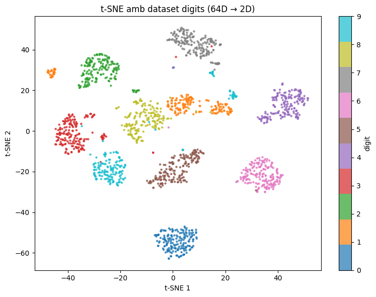

```python
# t-SNE sobre digits de 64D a 2D

# el paràmetre perplexity controla l'equilibri entre les relacions locals i globals. 30 és un valor equilibrat
tsne_digits = manifold.TSNE(n_components=2, random_state=seed, perplexity=30)
X_digits_tsne = tsne_digits.fit_transform(X)

fig, ax = plt.subplots(1, 1, figsize=(8, 6))
scatter = ax.scatter(X_digits_tsne[:,0], X_digits_tsne[:,1], c=y, s=5, cmap='tab10', alpha=0.7)
ax.set_xlabel('t-SNE 1')
ax.set_ylabel('t-SNE 2')
ax.set_title('t-SNE amb dataset digits (64D → 2D)')
plt.colorbar(scatter, ax=ax, label='dígit')
plt.tight_layout()
```

**Anàlisi:** El resultat de la reducció de dimensionalitat manté la separabilitat? Era d'esperar? Per què?

Clarament el t-SNE manté molt bé la separabilitat dels dígits. Es poden observar grups clarament definits per a cada dígit, amb molt poca superposició.

Era d'esperar, ja que se centra en preservar les relacions de veïnatge quan baixem de dimensió, de manera que punts propers en l'espai original estiguin també propers en reduïr dimensió. La idea és realment molt bona.

**Implementació:** Tria una mostra aleatòria o concreta del dataset i visualitza-la. Després redueix la dimensionalitat de tot el dataset a 1, 2, 3... fins a 40 dimensions amb t-SNE i inverteix el procés tractant de reconstruir les "imatges originals". Amb això fes dues coses: (1) Visualitza la imatge resultant de la reconstrucció de la mostra triada després de la reducció a 1, 2, ..., 5 dimensions. (2) Calcula l'error quadràtic mig (MSE) del dataset reconstruït respecte a l'original i visualitza l'error de reconstrucció en funció del nombre de dimensions al qual ha estat reduït (de 1 a 40 dimensions).

El primer a tenir en compte és que t-SNE no disposa d'un mètode d'inversió. Això és pq el t-SNE no aprèn cap funció explícita de transformació, sinó que calcula posicions concretes per a cada punt del dataset. Per tant, no existeix cap funció analítica que permeti fer el camí invers.

En vista d'això, per aproximar la inversa del t-SNE, una manera típica de procedir és la següent: s'entrena un regressor KNN que, donat un punt en l'espai reduït, prediu el vector original a partir de la mitjana dels seus k veïns més propers.

Un altre tema important: per defecte, t-SNE utilitza l'algorisme de Barnes-Hut (`method='barnes_hut'`), que és una aproximació que redueix la complexitat de $O(n^2)$ a $O(n \log n)$. Aquest mètode es basa en estructures d'arbre espacials (quad-tree en 2D, oct-tree en 3D) que no estan generalitzades a dimensions superiors, i per tant limita `n_components` a un màxim de 3. Com que l'exercici demana reduir fins a 40 dimensions, cal utilitzar `method='exact'`, que calcula les distàncies de forma exacta sense cap limitació en el nombre de components. El problema és que és significativament més lent, ja que la complexitat torna a ser $O(n^2)$.

Explico més en detall la inversa amb knn: un cop t-SNE ha reduït les 1797 mostres de 64D a nD, es busca per a cada punt els seus 6 veïns més propers a l'espai reduït (fem 6 i no 5 perquè el primer veí és sempre el propi punt, que descartem). Llavors, la reconstrucció de cada mostra és simplement la mitjana dels vectors originals de 64D dels seus 5 veïns:

$$X_{rec}[i] = \frac{1}{5} \sum_{j \in \text{veïns}(i)} X[j]$$

```
dim= 1  MSE=5.3858
dim= 2  MSE=3.9882
dim= 3  MSE=3.7027
dim= 4  MSE=3.6157
dim= 5  MSE=3.5782
dim= 8  MSE=3.5139
dim=12  MSE=3.4493
dim=16  MSE=3.4104
dim=20  MSE=3.3810
dim=24  MSE=3.3633
dim=28  MSE=3.3533
dim=32  MSE=3.3403
dim=36  MSE=3.3274
dim=40  MSE=3.3194
```

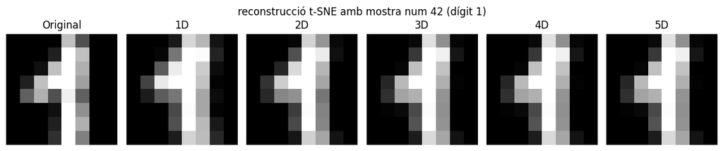

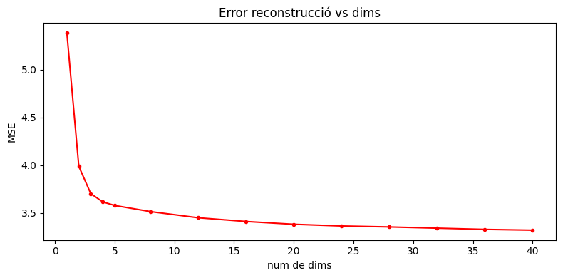

```python
# t-SNE no té inversa directa. Per reconstruir, utilitzarem
# KNN des de l'espai reduït cap a l'original (és una aproximació).
# Busquem 6 veïns i descartem el primer (que és el propi punt) per evitar biaix.
from sklearn.neighbors import NearestNeighbors

sample_idx_digit_tsne = 42
sample_image_tsne = X[sample_idx_digit_tsne].reshape(8, 8)

max_tsne_dims = 40

# Calculem t-SNE i reconstrucció per dims seleccionades (de 4 en 4)
dims_tsne_list = list(range(1, 6)) + list(range(8, max_tsne_dims + 1, 4))  # 1,2,3,4,5,8,12,...,40
dims_tsne_list = sorted(set(dims_tsne_list))
mse_values_tsne = []
reconstructions_tsne = {}

for n_comp in dims_tsne_list:
    # afegim method='exact' ja que sinó limita a 3 dims
    tsne_temp = manifold.TSNE(n_components=n_comp, method='exact', random_state=seed, perplexity=30)
    X_tsne_reduced = tsne_temp.fit_transform(X)
    # Busquem 6 veïns i descartem el propi punt (índex 0)
    nn = NearestNeighbors(n_neighbors=6)
    nn.fit(X_tsne_reduced)
    _, indices = nn.kneighbors(X_tsne_reduced)
    neighbor_indices = indices[:, 1:]  # descartem el propi punt
    X_tsne_reconstructed = np.mean(X[neighbor_indices], axis=1)
    mse = np.mean((X - X_tsne_reconstructed) ** 2)
    mse_values_tsne.append(mse)
    if n_comp <= 5:
        reconstructions_tsne[n_comp] = X_tsne_reconstructed
    print(f'dim={n_comp:2d}  MSE={mse:.4f}')

# visualitzem reconstruccions
fig, axes = plt.subplots(1, 6, figsize=(12, 2.5))
axes[0].imshow(sample_image_tsne, cmap='gray')
axes[0].set_title('Original')

for i, n_comp in enumerate(range(1, 6)):
    axes[i+1].imshow(reconstructions_tsne[n_comp][sample_idx_digit_tsne].reshape(8, 8), cmap='gray')
    axes[i+1].set_title(f'{n_comp}D')

for ax in axes:
    ax.axis('off')
plt.suptitle(f'reconstrucció t-SNE amb mostra num {sample_idx_digit_tsne} (dígit {y[sample_idx_digit_tsne]})')
plt.tight_layout()

# Calculem MSE per a les dimensions seleccionades i grafiquem
fig, ax = plt.subplots(1, 1, figsize=(8, 4))
ax.plot(dims_tsne_list, mse_values_tsne, 'ro-', markersize=3)
ax.set_xlabel('num de dims')
ax.set_ylabel('MSE')
ax.set_title('Error reconstrucció vs dims')
plt.tight_layout()
```

**Anàlisi:** Com afecta la reducció de dimensionalitat respecte a la informació mantinguda de la imatge? És lineal la relació? Per què?

Primer de tot, fixem-nos que les 5 imatges reconstruides son molt iguals. Això és normal, ja que tal i com hem aproximat la inversa, es fa una mitjana dels 5 veïns més propers, i ja hem comentat que t-sne preserva molt bé l'estructura local fins i tot amb poques dimensions. Per tant és normal.

Com ja hem comentat, t-SNE no disposa d'una funció inversa, ja que no genera una projecció lineal explícita sinó que resol un problema d'optimització. És per aquest motiu que la reconstrucció que hem creat és aproximada i, per tant, el MSE també.

Dit això, observem que el pas d'1D a 2D suposa una gran millora, però de 2D a 3D la millora és menor. A partir de 3D la millora ja és molt baixa (cada cop més). De fet, ja he comentat que el més natural és utilitzar method='barnes_hut', que limita a 3D, i per tant, amb això vull dir que amb t-sne, 2D i 3D solen ser suficients.

L'algorisme [UMAP](https://umap-learn.readthedocs.io/en/latest/) és més recent i també permet realitzar reduccions de dimensionalitat de manera no lineal, però en aquest cas projectant d'un espai a l'altre, no resolent un problema d'optimització. Hi ha una comparativa molt interessant entre *t-SNE* i *UMAP* [aquí](https://pair-code.github.io/understanding-umap/).

**Implementació:** realitzar una reducció de dimensionalitat amb *UMAP* per passar de 64 dimensions a 2 i crear una visualització on el color dels punts depengui del dígit al qual pertany.

Mentres usem UMAP, no farem servir el paràmetre random_state, ja que sinó no fa servir tots processadors. Si no fem servir random_state, per defecte tenim n_jobs=-1, que vol dir que usarà tots els processadors del PC per fer el càlcul.

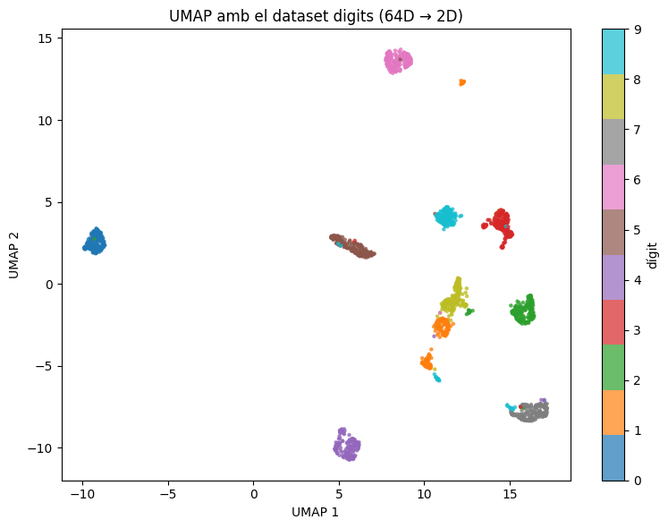

```python
umap_digits = UMAP(n_components=2)
X_digits_umap = umap_digits.fit_transform(X)

fig, ax = plt.subplots(1, 1, figsize=(8, 6))
scatter = ax.scatter(X_digits_umap[:,0], X_digits_umap[:,1], c=y, s=5, cmap='tab10', alpha=0.7)
ax.set_xlabel('UMAP 1')
ax.set_ylabel('UMAP 2')
ax.set_title('UMAP amb el dataset digits (64D → 2D)')
plt.colorbar(scatter, ax=ax, label='dígit')
plt.tight_layout()
```

**Anàlisi:** El resultat de la reducció de dimensionalitat manté la separabilitat? ¿Era d'esperar? Per què?

Podem afirmar que UMAP ha descrit molt bé la separabilitat, amb clusters compactes i ben definits per a cada dígit. El resultat és bastant igual o inclus millor que t-SNE, amb grups més separats.

Clarament era d'esperar, ja que de la mateixa manera que t-SNE, umap preserva l'estructura local de les dades. A més, UMAP preserva millor l'estructura global (i.e. entén millor les distàncies entre clusters) i segons he llegit és computacionalment més eficient que t-sne.

Reduir la dimensionalitat té una gran implicació: la pèrdua d'informació. Però en quin grau afecta a la dada?

**Implementació:** Tria una mostra aleatòria o concreta del dataset i visualitza-la. Després redueix la dimensionalitat de tot el dataset a 1, 2, 3... fins a 40 dimensions amb UMAP i inverteix el procés tractant de reconstruir les "imatges originals". Amb això fes dues coses: (1) Visualitza la imatge resultant de la reconstrucció de la mostra triada després de la reducció a 1, 2, ..., 5 dimensions. (2) Calcula l'error quadràtic mig (MSE) del dataset reconstruït respecte a l'original i visualitza l'error de reconstrucció en funció del nombre de dimensions al qual ha estat reduït (de 1 a 40 dimensions).

UMAP sí que té funció inversa (inverse_transform), però la documentació avisa amb un warning que diu que la inversió funciona millor amb embeddings de baixa dimensio i pot tot fallar quan augmenten les dims.

Per aquest motiu fem la gràfica fins a dim 5 (2, 3, 4 i 5), on la inversa és fiable i el cost computacional és baix. A partir de la dim=6 salta el warning que hem comentat i va extremadament lent.

```
dim= 2  MSE=7.4786
dim= 3  MSE=7.4404
dim= 4  MSE=7.3813
dim= 5  MSE=7.3064
```

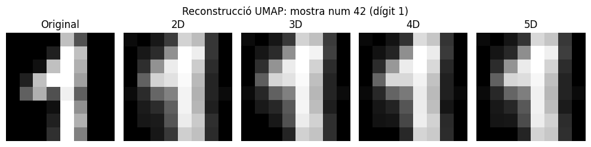

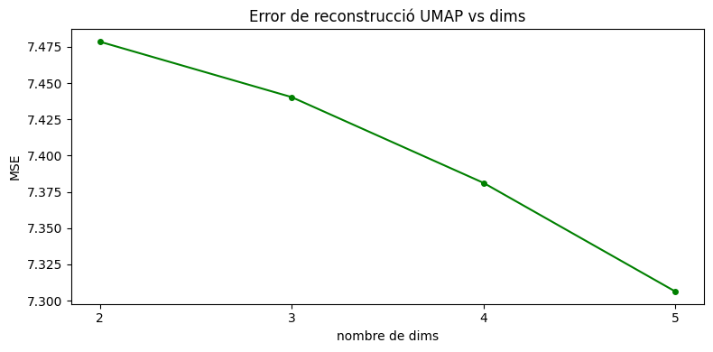

```python
sample_idx_digit_umap = 42
sample_image_umap = X[sample_idx_digit_umap].reshape(8, 8)

# visualitzem reconstruccions per a 2,..,5 dims (1D no suporta inverse_transform)
dims_umap_list = list(range(2, 6))  # 2,3,4,5
mse_values_umap = []

fig, axes = plt.subplots(1, 5, figsize=(10, 2.5))
axes[0].imshow(sample_image_umap, cmap='gray')
axes[0].set_title('Original')

for i, n_comp in enumerate(dims_umap_list):
    umap_temp = UMAP(n_components=n_comp)
    X_umap_reduced = umap_temp.fit_transform(X)
    X_umap_reconstructed = umap_temp.inverse_transform(X_umap_reduced)
    axes[i + 1].imshow(X_umap_reconstructed[sample_idx_digit_umap].reshape(8, 8), cmap='gray')
    axes[i + 1].set_title(f'{n_comp}D')

    mse = np.mean((X - X_umap_reconstructed) ** 2)
    mse_values_umap.append(mse)
    print(f'dim={n_comp:2d}  MSE={mse:.4f}')

for ax in axes:
    ax.axis('off')
plt.suptitle(f'Reconstrucció UMAP: mostra num {sample_idx_digit_umap} (dígit {y[sample_idx_digit_umap]})')
plt.tight_layout()

fig, ax = plt.subplots(1, 1, figsize=(8, 4))
ax.plot(dims_umap_list, mse_values_umap, 'go-', markersize=4)
ax.set_xlabel('nombre de dims')
ax.set_ylabel('MSE')
ax.set_title('Error de reconstrucció UMAP vs dims')
ax.set_xticks(dims_umap_list)
plt.tight_layout()
```

**Anàlisi:** Com afecta la reducció de dimensionalitat respecte a la informació mantinguda de la imatge? És lineal la relació? Per què?

### 2.3 Agrupament d'imatges

Emprant el mateix dataset executa l'algorisme *k-means* ($k=10$) en quatre escenaris: sobre les dades originals (64D), després d'aplicar una reducció *PCA* a 2D, després d'una reducció *t-SNE* a 2D, i després d'una reducció amb *UMAP* a 2D.

Per saber si la reducció de dimensionalitat contribueix de manera positiva o negativa al clustering posterior avaluaràs l'agrupament emprant la mètrica [ARI (Adjusted Rand Index)](https://scikit-learn.org/stable/modules/generated/sklearn.metrics.adjusted_rand_score.html), ja que en aquest cas comptem amb les etiquetes originals del dataset.

**Implementació:** per al primer cas no redueixis la dimensionalitat del dataset, simplement aplica *k-means* i mostra l'ARI del resultat.

```python
km_original = cluster.KMeans(n_clusters=n_clusters, random_state=seed, n_init=10)
labels_km_original = km_original.fit_predict(X)
ari_original = adjusted_rand_score(y, labels_km_original)
print(f"ARI (dades originals 64D): {ari_original:.4f}")
```

```
ARI (dades originals 64D): 0.6669
```

**Implementació:** redueix la dimensionalitat del dataset amb *PCA*, aplica *k-means* i mostra l'ARI del resultat.

```python
km_pca = cluster.KMeans(n_clusters=n_clusters, random_state=seed, n_init=10)
labels_km_pca = km_pca.fit_predict(X_digits_pca)
ari_pca = adjusted_rand_score(y, labels_km_pca)
print(f"ARI (PCA 2D): {ari_pca:.4f}")
```

```
ARI (PCA 2D): 0.3880
```

**Implementació:** redueix la dimensionalitat del dataset amb *t-SNE*, aplica *k-means* i mostra l'ARI del resultat.

```python
km_tsne = cluster.KMeans(n_clusters=n_clusters, random_state=seed, n_init=10)
labels_km_tsne = km_tsne.fit_predict(X_digits_tsne)
ari_tsne = adjusted_rand_score(y, labels_km_tsne)
print(f"ARI (t-SNE 2D): {ari_tsne:.4f}")
```

```
ARI (t-SNE 2D): 0.8891
```

**Implementació:** redueix la dimensionalitat del dataset amb *UMAP*, aplica *k-means* i mostra l'ARI del resultat.

```python
km_umap = cluster.KMeans(n_clusters=n_clusters, random_state=seed, n_init=10)
labels_km_umap = km_umap.fit_predict(X_digits_umap)
ari_umap = adjusted_rand_score(y, labels_km_umap)
print(f"ARI (UMAP 2D): {ari_umap:.4f}")
```

```
ARI (UMAP 2D): 0.8359
```

**Anàlisi:** Com ha afectat la reducció de dimensionalitat al clustering posterior? Per què?

- La reducció amb PCA ha empitjorat el clústering, tal i com ja hem pogut veure abans observant com ha quedat la PCA en 2D.
- Tant t-SNE com UMAP han millorat el clústering, com ja hem pogut observar als gràfics que hem generat anteriorment.

Això es deu a que aquests mètodes no lineals (t-sne i umap) preserven l'estructura local, creant clusters compactes i ben separats en 2D que k-means pot identificar fàcilment.

En aprenentatge no supervisat normalment no es disposa d'etiquetes, per la qual poques vegades se sol recórrer a la matriu de confusió per comprovar els resultats. Però com que en aquest cas sí que es disposa d'elles, un exercici interesant és mirar quins números es confonen amb altres números per la seva grafia. Per a això és possible definir una etiqueta al clúster en base a l'etiqueta de moda entre totes les etiquetes presents en les mostres que pertanyen a aquest clúster (jugarien el paper de "prediccions"). D'altra banda, es disposa de les etiquetes reals, per la qual cosa és possible elaborar la matriu de confusió.

**Implementació:** genera la matriu de confusió comparant els dígits reals amb les etiquetes assignades en base a la moda del clúster. Visualitza els resultats en un mapa de calor per detectar quins parells de números presenten similituds en els seus traços (com l'1 amb el 8 o el 3 amb el 9) que provoquen que l'algorisme els agrupi en un mateix clúster.

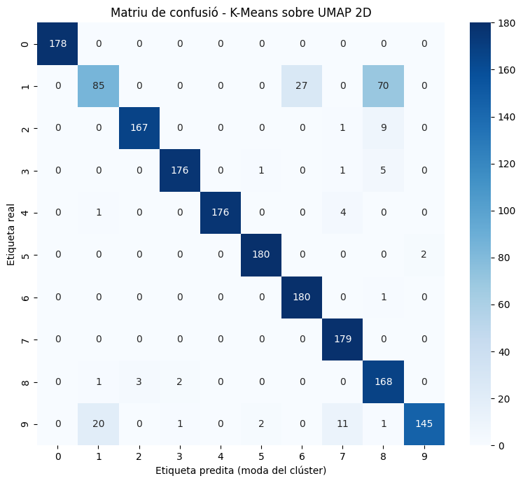

```python
# partim de umap + k-means
labels_best = labels_km_umap

# assignem etiqueta de moda a cada cluster
cluster_labels = np.zeros_like(labels_best)
for i in range(n_clusters):
    mask = labels_best == i
    cluster_labels[mask] = mode(y[mask], keepdims=False).mode

# generem matriu de confusió
cm = confusion_matrix(y, cluster_labels)

fig, ax = plt.subplots(1, 1, figsize=(8, 7))
sns.heatmap(cm, annot=True, fmt='d', cmap='Blues', ax=ax,
            xticklabels=range(10), yticklabels=range(10))
ax.set_xlabel('Etiqueta predita (moda del clúster)')
ax.set_ylabel('Etiqueta real')
ax.set_title('Matriu de confusió - K-Means sobre UMAP 2D')
plt.tight_layout()
```

**Anàlisi:** Quins dígits tendeixen a confondre's amb quins altres? Té sentit?

- El dígit 1 es confon amb el 8 (70 mostres).
- El dígit 1 es confon amb el 6 (27 mostres).
- El dígit 9 es confon amb l'1 (20 mostres).

Mirant la forma dels nombres, té bastant sentit.

Atès que *k-means* calcula els centroides dels diferents grups que identifica, podem trobar l'exemple "canònic" de cadascun d'ells.

**Implementació:** busca 10 grups amb *k-means* en les dades brutes (alta dimensionalitat), extreu els centroides trobats i visualitza'ls.

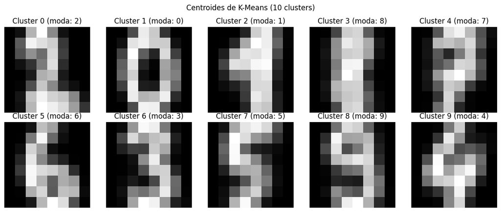

```python
# k-means sobre dades originals per obtenir centroides
km_centroids = cluster.KMeans(n_clusters=n_clusters, random_state=seed, n_init=10)
km_centroids.fit(X)

# visualitzem
fig, axes = plt.subplots(2, 5, figsize=(12, 5))
for i, ax in enumerate(axes.reshape(-1)):
    ax.imshow(km_centroids.cluster_centers_[i].reshape(8, 8), cmap='gray')
    # etiqueta de centroide basada en la moda
    mask = km_centroids.labels_ == i
    label = mode(y[mask], keepdims=False).mode
    ax.set_title(f'Cluster {i} (moda: {label})')
    ax.axis('off')

plt.suptitle('Centroides de K-Means (10 clusters)')
plt.tight_layout()
```

### 2.4 Interpolació d'imatges

Al representar les imatges com a vectors és possible conèixer el que succeeix en punts intermedis de l'espai (molt similar al que succeeix en els models generatius de difusió).

És possible interpolar imatges tant en alta dimensionalitat com reduint, desplaçant-nos en l'espai de baixa dimensionalitat, i invertint la reducció en cadascun dels passos.

**Implementació:** tria dos centroides (pot ser a l'atzar), pots projectar a baixa dimensionalitat amb algun dels mètodes vists (serà necessari invertir l'operació), calcula les coordenades de 6 punts intermedis en el camí entre els dos centroides i mostra les imatges reconstruïdes de cadascun dels punts intermedis de la interpolació.

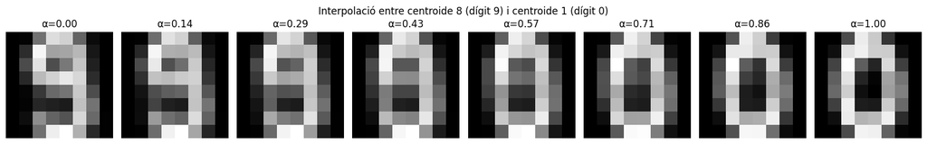

```python
# ho faig directament en la dimensió original, sense projectar, ja que construir
# una línea entre 2 punts es fa igual en 2D que en qualsevol dimensió
np.random.seed(seed)
idx_a, idx_b = np.random.choice(n_clusters, size=2, replace=False)
centroid_a = km_centroids.cluster_centers_[idx_a]
centroid_b = km_centroids.cluster_centers_[idx_b]

# fem 6 punts intermedis (+ 2 extrems = 8 imatges)
n_steps = 8
alphas = np.linspace(0, 1, n_steps)

fig, axes = plt.subplots(1, n_steps, figsize=(16, 2.5))
for i, alpha in enumerate(alphas):
    interpolated = (1 - alpha) * centroid_a + alpha * centroid_b
    axes[i].imshow(interpolated.reshape(8, 8), cmap='gray')
    axes[i].set_title(f'α={alpha:.2f}')
    axes[i].axis('off')

label_a = mode(y[km_centroids.labels_ == idx_a], keepdims=False).mode
label_b = mode(y[km_centroids.labels_ == idx_b], keepdims=False).mode
plt.suptitle(f'Interpolació entre centroide {idx_a} (dígit {label_a}) i centroide {idx_b} (dígit {label_b})')
plt.tight_layout()
```

### 2.5 Detecció d'*outliers*

És possible identificar imatges "anòmales" emprant tècniques de detecció d'anomalies com [isolation forest](https://en.wikipedia.org/wiki/Isolation_forest).

**Implementació:** aplica isolation forest al conjunt original i visualitza les 5 imatges amb major grau d'anomalia, indica també la seva etiqueta i la seva puntuació com a outlier proporcionada per isolation forest.

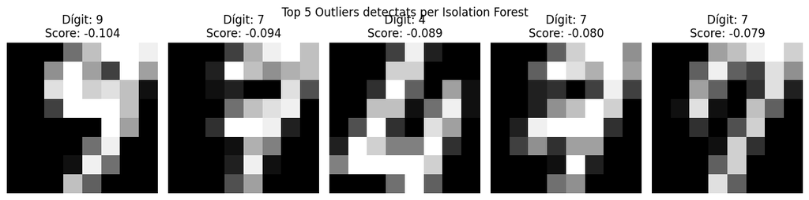

```python
# apliquem isolation sobre les dades originals. Amb el paràmetre contamination='auto'
# el model estima automàticament el percentatge d'anomalies del dataset
iso_forest = ensemble.IsolationForest(random_state=seed, contamination='auto')
iso_forest.fit(X)

# obtenim puntuacions. més negatiu vol dir més anòmal (i.e. easier d'aïllar)
scores = iso_forest.decision_function(X)

# agafem les 5 mostres més anòmales
top5_outlier_idx = np.argsort(scores)[:5]

fig, axes = plt.subplots(1, 5, figsize=(12, 3))
for i, idx in enumerate(top5_outlier_idx):
    axes[i].imshow(X[idx].reshape(8, 8), cmap='gray')
    axes[i].set_title(f'Dígit: {y[idx]}\nScore: {scores[idx]:.3f}')
    axes[i].axis('off')

plt.suptitle('Top 5 Outliers detectats per Isolation Forest')
plt.tight_layout()
```

**Anàlisi:** si haguessis de donar-li un significat al concepte d'anomalia en aquest dataset veient els resultats, quin seria?

En aquest context, el concepte d'anomalia voldria dir imatges de dígits que estan mal escrits o que estan escrits de manera confusa (és a dir, estar deformats o tenen traços atípics).